# ECON03GE3A

2021-08-20

## Reference

The Colonial Legacy

Chandra (2004)

[figure not shown]

## The Colonial Structure

The four basic features of the colonial structure in India:

- Complete but complex integration and enmeshing of the colony with the world capitalist system in a subordinate position.
- Unequal exchange and internal disarticulation of the economy India’s Foreign Trade
- Availability and utilisation of surpluses for development was low. Capital Formation and Savings 1901-46
  - Why was the availability of surplus low?
    - Drain
    - Appropriation by the colonial state
    - Landlords and moneylenders
- Policies of the colonial state in the subordination of India.

## Colonial Impact on Agriculture

- Severe impact during the first half of the twentieth century.
  - Per capita agricultural production declined by 0.72% per year during 1911-14.
  - Per capita food grain output declined by 1.14% per year.
- Colonialism made the agrarian structure extremely regressive.
  - *Zamindars* failed to invest in land.
  - More reliance on rack-renting.
  - Peasants lost land to the moneylenders.
  - Sub infeudation, tenancy, and sharecropping dominated the *zamindari* and the *ryotwari* areas.
- No change in the technology or techniques and inputs.

  | Technology | Statistics |
  | --- | --- |
  | No. of ploughs used in India (late 1930s) | 32 million |
  | Agricultural department selling improved ploughs | 7 to 8 thousand per year |
  | Use of improved seeds (1922-23) | 1.9% |
  | Use of chemical fertilizers | 2000 tonnes per year (1898-1923) 17,400 tonnes per year (1919-24) |
  | Number of agricultural colleges in 1946 | 9 with 3110 students |
  | Investment in terracing, flood control, drainage and de-salinization of soil | Nil |
  | % of total cultivated area irrigated | 26.7% in 1940 |

## Colonial impact on Industry

- Decline in urban handicrafts
- Slow growth of modern industries
  - Confined to jute and textile
  - Iron and steel after 1907
  - Sugar, cement, and paper after 1930s
    - Depression induced weaknesses
- Cotton and jute accounted for 30% of workforce until 1946.
- Growth rate: 3.8% per annum
- Share of industry: 7.5% in 1918, 3.8% in 1913

## Colonial impact on Industry

- Employment:
  - In 1939, Population = 389 million, employed = 2 million
  - In 1951 - 2.3% employed in industry

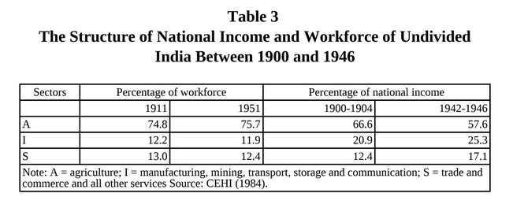

- Capital goods industry
  - Absence of capital goods industry.
  - Relied mostly on imported machinery or tools.
  - 89.9% of capital goods imported in 1950.

## Colonial impact on industry

- Banking Sector/industry
  - Underdeveloped

    | Year | Statistics |
    | --- | --- |
    | 1914 | 1 bank office for 1.7 million people |
    | 1940 | 1 bank office for 90,000 people |
    | 2009 | 1 bank office for 14 people |

- Trade
  - Imports \(\rightarrow\) indigenous industries, modern industries.
  - Displaced indigenous industries.

## Colonial impact on industry

- Railways
  - Commercial revolution \(\rightarrow\) colonialisation \(\rightarrow\) exports and distribution.
- Foreign investment
  - Uniliver, Imperial Chemical Industries, Dunlop, and General Motors entry after 1918.
  - Contributed to ‘guided underdevelopment’.
  - Production and export of raw materials and food stuffs.
  - Catered to foreign markets.

## Other economic indicators of backwardness

- Very slow growth in India’s national income and stagnation in per capita income

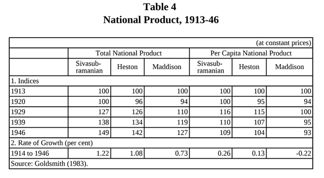

- - Angus Maddison: [The Maddison Project](https://www.rug.nl/ggdc/historicaldevelopment/maddison/releases/maddison-project-database-2020)
  - Alan Heston: [Penn World Table](https://www.rug.nl/ggdc/productivity/pwt/)

## Other economic indicators of backwardness

| Year | Statistics |
| --- | --- |
| Cereals and Pulses availability (1950) | 394.9 grams/day/person |
| Availability of cloth (1950) | 10 meters/year/person |
| Death rate (1950) | 27.4 / 1000 persons |
| Infant Mortality Rate (1950) | 175 - 190 / 1000 live births |
| Life expectancy (1950) | 32 years |
| No of medical colleges (1943) | 10 with 700 graduates |
| No of medical doctors (1951) | 18000 |
| Cases of small pox, plague, and cholera deaths | in millions |
| % of illiterate population (1947) | 88% |

## Summary::India’s economic profile in 1940s

- Stagnating per capita national income.
- Abysmal standard of living.
- Stunted industrial development
- Stagnant, low-productivity, semi-fudal agriculture.